# MRP Validation Report

Meinungsbild

Published

April 7, 2026

```r
library(tidyverse)
library(knitr)

mb_root    <- here::here()
val_dir    <- file.path(mb_root, "output", "validation")
checks_dir <- file.path(mb_root, "output", "checks")
```

## Overview

This report summarizes validation tests for the Meinungsbild MRP estimates. Each section compares MRP-predicted quantities against observed ground truth. The goal is to assess how well the model recovers known geographic variation in outcomes that can be independently measured.

[output not shown]

## 1. Vote share validation (2021 only, no election covariates)

We re-fit vote intention models using only 2021 survey data (N = 4,954 respondents from GLES Tracking + Cross-Section Cumulation, 245 Kreise with respondents) and compare county-level predictions against actual BTW 2021 second-vote shares.

- **Baseline 2020-2021:** Demographics + log population density + geographic random effects, using 2020-2021 data (7,097 obs, 7,704 respondents)
- **Baseline 2021:** Same spec, 2021 data only (4,533 obs, 4,954 respondents)
- **All INKAR:** Baseline 2021 + four socioeconomic covariates (foreign-born share, median income, rent, refugee share)
- **LASSO-selected:** glmmLasso selects which INKAR covariates to include per issue via BIC-tuned L1 penalization, then refits with glmer

```r
val_2021 <- read_csv(file.path(val_dir, "vote_share_validation_2021only.csv"),
                     show_col_types = FALSE)

spec_labels <- c(baseline = "Baseline", baseline_inkar = "All INKAR",
                 lasso_select = "LASSO-selected")

val_2021 |>
  mutate(Spec = spec_labels[spec]) |>
  select(Spec, Party = party, `r` = r, `RMSE (pp)` = rmse_pp,
         `Bias (pp)` = bias_pp, `MRP mean (%)` = mean_mrp,
         `Actual mean (%)` = mean_actual) |>
  kable(digits = c(0, 0, 3, 1, 1, 1, 1))
```

| Spec | Party | r | RMSE (pp) | Bias (pp) | MRP mean (%) | Actual mean (%) |
| --- | --- | --- | --- | --- | --- | --- |
| NA | DIE LINKE | 0.873 | 2.0 | 1.3 | 5.9 | 4.6 |
| NA | AfD | 0.858 | 4.8 | -2.8 | 8.6 | 11.4 |
| NA | SPD | 0.840 | 4.0 | 1.4 | 27.1 | 25.7 |
| NA | CDU/CSU | 0.807 | 4.4 | -2.1 | 23.0 | 25.0 |
| NA | Grüne | 0.799 | 6.5 | 5.5 | 18.3 | 12.8 |
| NA | FDP | 0.587 | 2.1 | 1.0 | 12.1 | 11.1 |
| Baseline | DIE LINKE | 0.859 | 1.9 | 1.1 | 5.7 | 4.6 |
| Baseline | AfD | 0.852 | 4.6 | -3.0 | 8.4 | 11.4 |
| Baseline | CDU/CSU | 0.800 | 4.3 | -1.6 | 23.4 | 25.0 |
| Baseline | SPD | 0.796 | 4.3 | 1.5 | 27.2 | 25.7 |
| Baseline | Grüne | 0.791 | 6.4 | 5.3 | 18.1 | 12.8 |
| Baseline | FDP | 0.598 | 2.0 | 0.9 | 12.0 | 11.1 |
| All INKAR | DIE LINKE | 0.819 | 2.1 | 1.2 | 5.8 | 4.6 |
| All INKAR | Grüne | 0.796 | 6.5 | 5.3 | 18.1 | 12.8 |
| All INKAR | AfD | 0.773 | 4.9 | -2.9 | 8.5 | 11.4 |
| All INKAR | SPD | 0.772 | 4.5 | 1.8 | 27.4 | 25.7 |
| All INKAR | CDU/CSU | 0.750 | 4.5 | -1.6 | 23.4 | 25.0 |
| All INKAR | FDP | 0.509 | 2.2 | 0.8 | 11.9 | 11.1 |
| LASSO-selected | DIE LINKE | 0.820 | 2.1 | 1.1 | 5.8 | 4.6 |
| LASSO-selected | AfD | 0.804 | 4.7 | -2.9 | 8.4 | 11.4 |
| LASSO-selected | Grüne | 0.796 | 6.5 | 5.3 | 18.1 | 12.8 |
| LASSO-selected | SPD | 0.767 | 4.6 | 1.8 | 27.5 | 25.7 |
| LASSO-selected | CDU/CSU | 0.752 | 4.6 | -1.6 | 23.4 | 25.0 |
| LASSO-selected | FDP | 0.623 | 1.9 | 0.8 | 11.9 | 11.1 |

```r
val_2021 |>
  group_by(spec) |>
  summarise(`Median r` = round(median(r), 3),
            `Median RMSE (pp)` = round(median(rmse_pp), 1),
            `Median |bias| (pp)` = round(median(abs(bias_pp)), 1),
            .groups = "drop") |>
  mutate(Spec = spec_labels[spec]) |>
  select(Spec, everything(), -spec) |>
  kable()
```

| Spec | Median r | Median RMSE (pp) | Median \|bias\| (pp) |
| --- | --- | --- | --- |
| Baseline | 0.798 | 4.3 | 1.5 |
| NA | 0.824 | 4.2 | 1.7 |
| All INKAR | 0.773 | 4.5 | 1.7 |
| LASSO-selected | 0.781 | 4.6 | 1.7 |

The 2020-2021 baseline (more data, minimal temporal mismatch) achieves the highest median correlation. Among the 2021-only specs, the baseline outperforms both covariate-enriched alternatives. Adding INKAR covariates without regularization reduces performance due to overfitting; LASSO selection partially mitigates this but still does not beat the baseline. The geographic random effects already capture the variation these covariates would add. More survey data is the strongest lever for improving estimates.

```r
knitr::include_graphics(file.path(val_dir, "vote_share_scatter_2021only.pdf"))
```

[figure not shown]

MRP predicted vs. actual BTW 2021 county-level vote shares (2021 survey data only). Three specifications compared: baseline (demographics + pop density), all INKAR covariates, and LASSO-selected covariates.

## 2. Internal consistency: Bundesland direct vs. MRP

The main pipeline (08_check_pipeline.R) compares MRP Bundesland estimates against direct survey means for all 49 issues. This is not a true external validation (it uses the same survey data), but it checks whether the model’s geographic smoothing distorts aggregate patterns.

```r
val_bl <- read_csv(file.path(checks_dir, "validation_bundesland.csv"),
                   show_col_types = FALSE)

tibble(
  Metric = c("N issues", "Median r", "Median RMSE",
             "Issues with r < 0.5", "Issues with r > 0.9"),
  Value  = c(
    nrow(val_bl),
    round(median(val_bl$r, na.rm = TRUE), 3),
    paste0(round(100 * median(val_bl$rmse, na.rm = TRUE), 1), " pp"),
    sum(val_bl$r < 0.5, na.rm = TRUE),
    sum(val_bl$r > 0.9, na.rm = TRUE)
  )
) |> kable()
```

| Metric | Value |
| --- | --- |
| N issues | 49 |
| Median r | 0.899 |
| Median RMSE | 5.4 pp |
| Issues with r < 0.5 | 4 |
| Issues with r > 0.9 | 24 |

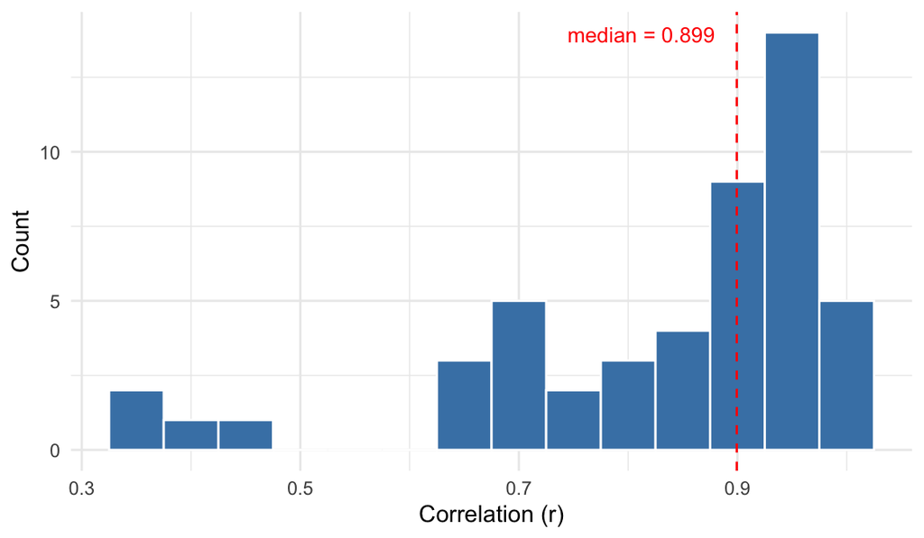

Distribution of Bundesland-level correlations (MRP vs. direct survey means) across 49 issues.

```r
val_bl |>
  ggplot(aes(x = r)) +
  geom_histogram(binwidth = 0.05, fill = "steelblue", color = "white") +
  geom_vline(xintercept = median(val_bl$r, na.rm = TRUE),
             linetype = "dashed", color = "red") +
  annotate("text", x = median(val_bl$r, na.rm = TRUE) - 0.02,
           y = Inf, label = paste0("median = ", round(median(val_bl$r, na.rm = TRUE), 3)),
           vjust = 2, hjust = 1, size = 3.5, color = "red") +
  labs(x = "Correlation (r)", y = "Count") +
  theme_minimal(base_size = 11)
```

## Summary

```r
val_2021 |>
  group_by(spec) |>
  summarise(`Median r` = median(r),
            `Median RMSE (pp)` = median(rmse_pp),
            .groups = "drop") |>
  mutate(Spec = spec_labels[spec]) |>
  select(Spec, everything(), -spec) |>
  bind_rows(
    tibble(Spec = "Bundesland direct vs. MRP (49 issues)",
           `Median r` = median(val_bl$r, na.rm = TRUE),
           `Median RMSE (pp)` = 100 * median(val_bl$rmse, na.rm = TRUE))
  ) |>
  kable(digits = c(0, 3, 1))
```

| Spec | Median r | Median RMSE (pp) |
| --- | --- | --- |
| Baseline | 0.798 | 4.3 |
| NA | 0.824 | 4.2 |
| All INKAR | 0.773 | 4.5 |
| LASSO-selected | 0.781 | 4.6 |
| Bundesland direct vs. MRP (49 issues) | 0.899 | 5.4 |

The best-performing external validation spec uses 2020-2021 survey data (7,704 respondents, 245 Kreise) with no election covariates, achieving a median county-level correlation of 0.82 and RMSE of 4.2 pp. Within the 2021-only data, the baseline specification outperforms covariate-enriched alternatives. The main lever for improving estimates is more survey data with geographic identifiers, not model complexity.